# Using Prophet on the Dedman Data

Chad Madding

4/8/2020

## R API

In R, we use the normal model fitting API. We provide a prophet function that performs fitting and returns a model object. You can then call predict and plot on this model object.

All information available here: https://facebook.github.io/prophet/docs/quick_start.html#r-api

First we read in the data and create the outcome variable. As in the Python API, this is a dataframe with columns ds and y, containing the date and numeric value respectively. The ds column should be YYYY-MM-DD for a date, or YYYY-MM-DD HH:MM:SS for a timestamp.

```r
df <- read.csv('DedmanDailySwipe.csv')

colnames(df)[1] = "ds"
colnames(df)[2] = "y"

df = df[ , c(1, 2)]
```

We call the prophet function to fit the model. The first argument is the historical dataframe. Additional arguments control how Prophet fits the data and are described in later pages of this documentation.

[output not shown]

Predictions are made on a dataframe with a column ds containing the dates for which predictions are to be made. The make_future_dataframe function takes the model object and a number of periods to forecast and produces a suitable dataframe. By default it will also include the historical dates so we can evaluate in-sample fit.

```r
future <- make_future_dataframe(m, periods = 30)
tail(future)
```

```
##             ds
## 446 2020-04-05
## 447 2020-04-06
## 448 2020-04-07
## 449 2020-04-08
## 450 2020-04-09
## 451 2020-04-10
```

As with most modeling procedures in R, we use the generic predict function to get our forecast. The forecast object is a dataframe with a column yhat containing the forecast. It has additional columns for uncertainty intervals and seasonal components.

```r
forecast <- predict(m, future)
tail(forecast[c('ds', 'yhat', 'yhat_lower', 'yhat_upper')])
```

```
##             ds      yhat yhat_lower yhat_upper
## 446 2020-04-05  982.0764   617.3012   1342.857
## 447 2020-04-06 1690.5786  1329.8676   2076.002
## 448 2020-04-07 1647.6853  1315.0598   2017.887
## 449 2020-04-08 1642.8256  1308.0969   2014.208
## 450 2020-04-09 1396.5296  1044.3453   1773.905
## 451 2020-04-10 1276.6328   909.9287   1652.871
```

You can use the generic plot function to plot the forecast, by passing in the model and the forecast dataframe.

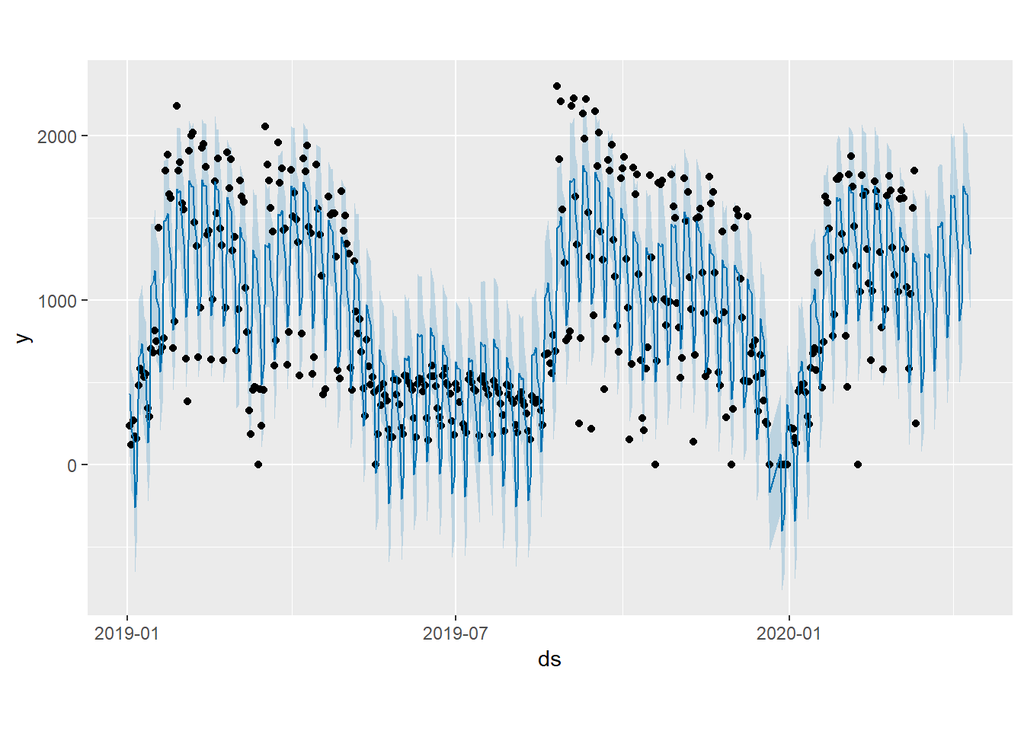

```r
plot(m, forecast)
```

You can use the prophet_plot_components function to see the forecast broken down into trend, weekly seasonality, and yearly seasonality.

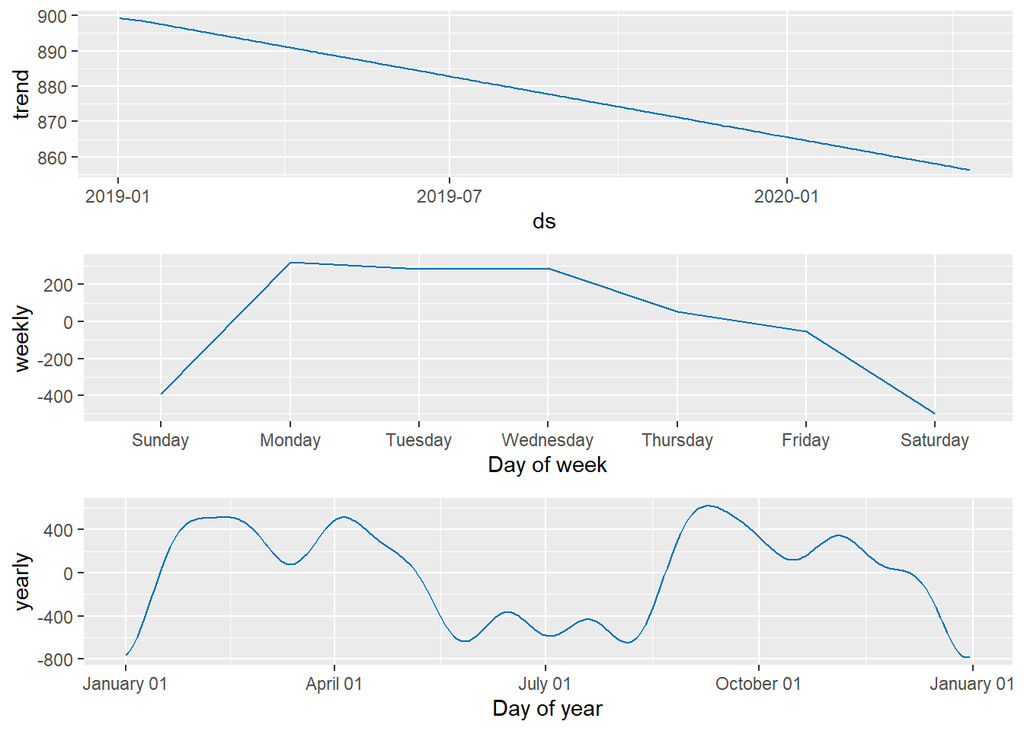

```r
prophet_plot_components(m, forecast)
```

An interactive plot of the forecast using Dygraphs can be made with the command dyplot.prophet(m, forecast).

```r
dyplot.prophet(m, forecast)
```

[interactive chart not shown]